# Test 6, вариант 11. Черкасов Владислав, группа 520

```r
origin <- na.omit(read.csv("data_11.txt", sep = "\t", header = TRUE))
```

Загружаем данные, переходя к ряду из приростов цен. Его стационарность проверим тестом Дики-Фуллера:

```r
data <- origin[-1,]
data$Price <- diff(origin$Price)
data$Date <- origin$Date[-1]
library(stats)
data <- ts(data[,2], start = c(1994,1), frequency = 52)
new_data <- window(data, start = c(2009,25), end = c(2014,36))
library(tseries)
tseries::adf.test(new_data, k=52)
```

```
##
##  Augmented Dickey-Fuller Test
##
## data:  new_data
## Dickey-Fuller = -3.4718, Lag order = 52, p-value = 0.0459
## alternative hypothesis: stationary
```

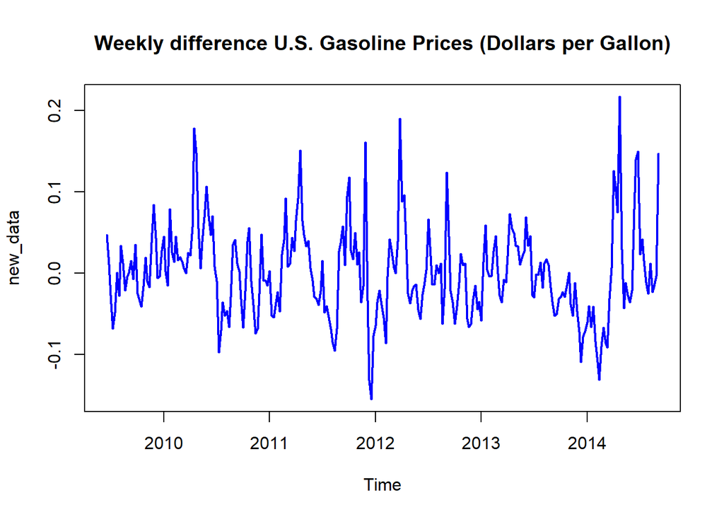

```r
plot(new_data ,type = "l", col = "blue",lwd = 2,main = "Weekly difference U.S. Gasoline Prices (Dollars per Gallon)")
```

Итак, полученный ряд можно считать стационарным в плане среднего значения. Пришлось немного отступить от исходных временных границ, чтобы добиться честной стационарности с точки зрения статистического теста, поскольку исходный промежуток времени был неидеален:

```r
tseries::adf.test(window(data, start = c(2010,1), end = c(2015,1)), k=52)
```

```
##
##  Augmented Dickey-Fuller Test
##
## data:  window(data, start = c(2010, 1), end = c(2015, 1))
## Dickey-Fuller = -3.0971, Lag order = 52, p-value = 0.1139
## alternative hypothesis: stationary
```

Построим графики ACF и PACF:

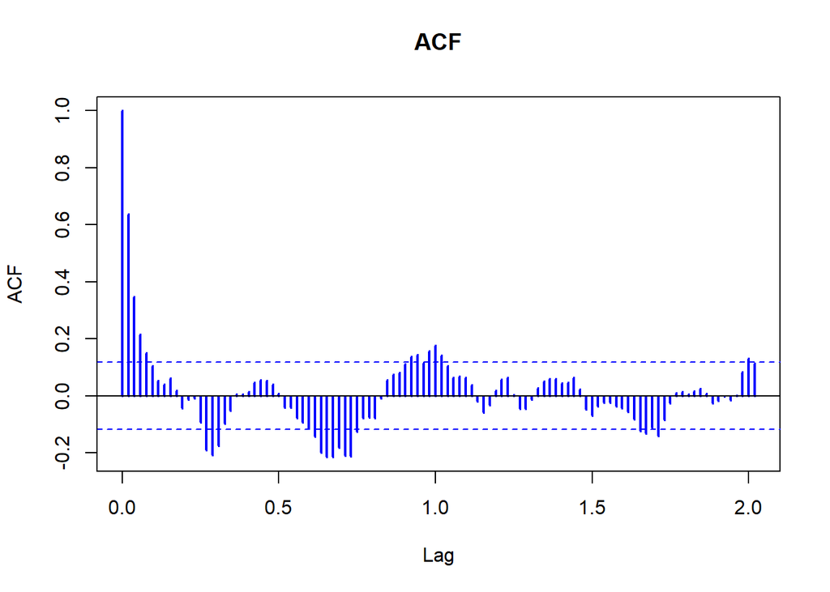

```r
acf(new_data, lwd = 2,main = "ACF",col = "blue",lag.max = 105)
```

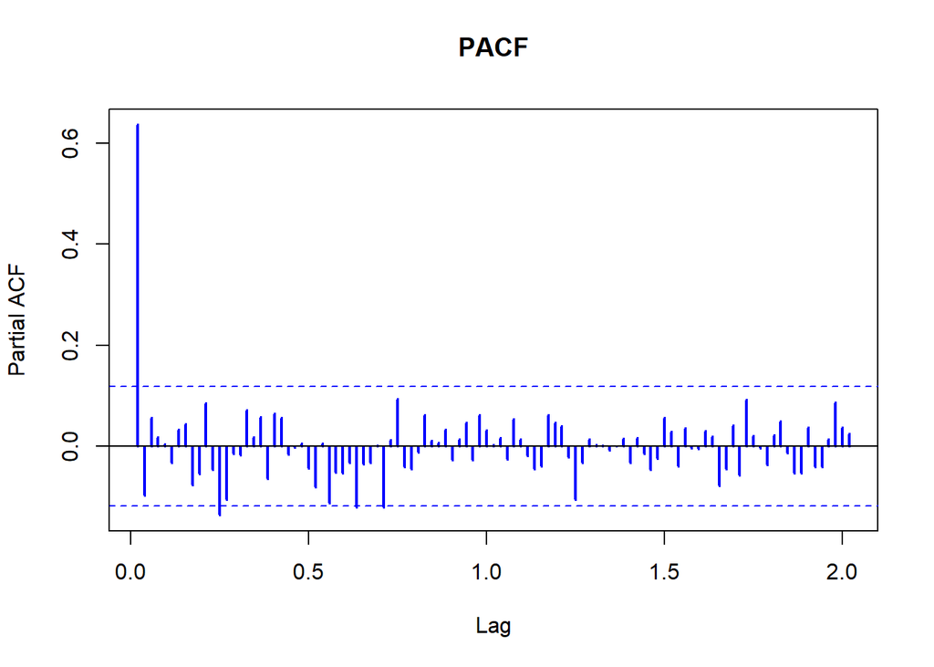

```r
pacf(new_data,lwd = 2,main = "PACF",col = "blue",lag.max=105)
```

График ACF обладает очень низкой скоростью затухания и большим количеством выбросов, поэтому требуется ориентироваться на график PACF, следовательно, будем считать, что данный временной ряд лучше описывать с помощью модели авторегрессии. Основываясь на этом графике, можно оценить порядок модели, как (1,0,0) с периодом сезонности 52, поскольку в году 52 недели. Проявления годовой сезонности не наблюдается, поэтому оставим сезонную компоненту нулевой. Для сравнения используем модель, которую предлагает функция автоматического подбора модели:

```r
library(forecast)
auto.arima(new_data)
```

```
## Series: new_data
## ARIMA(1,0,1)(0,0,1)[52] with zero mean
##
## Coefficients:
##          ar1     ma1    sma1
##       0.5234  0.2123  0.1001
## s.e.  0.0814  0.0948  0.0632
##
## sigma^2 = 0.0018:  log likelihood = 474.5
## AIC=-941   AICc=-940.85   BIC=-926.58
```

Оценим эти модели:

```r
library("lmtest")
arima_model <- arima(new_data,order = c(1,0,0),seasonal = list(order= c(0,0,0),period = 52),method = "ML")
coeftest(arima_model)
```

```
##
## z test of coefficients:
##
##            Estimate Std. Error z value Pr(>|z|)
## ar1       0.6524326  0.0466891 13.9740   <2e-16 ***
## intercept 0.0021792  0.0074190  0.2937    0.769
## ---
## Signif. codes:  0 '***' 0.001 '**' 0.01 '*' 0.05 '.' 0.1 ' ' 1
```

```r
AIC(arima_model)
```

```
## [1] -935.9264
```

```r
resid <- arima_model$residuals
Box.test(resid, lag = 52, type = "Ljung-Box", fitdf = 2)
```

```
##
##  Box-Ljung test
##
## data:  resid
## X-squared = 59.714, df = 50, p-value = 0.1634
```

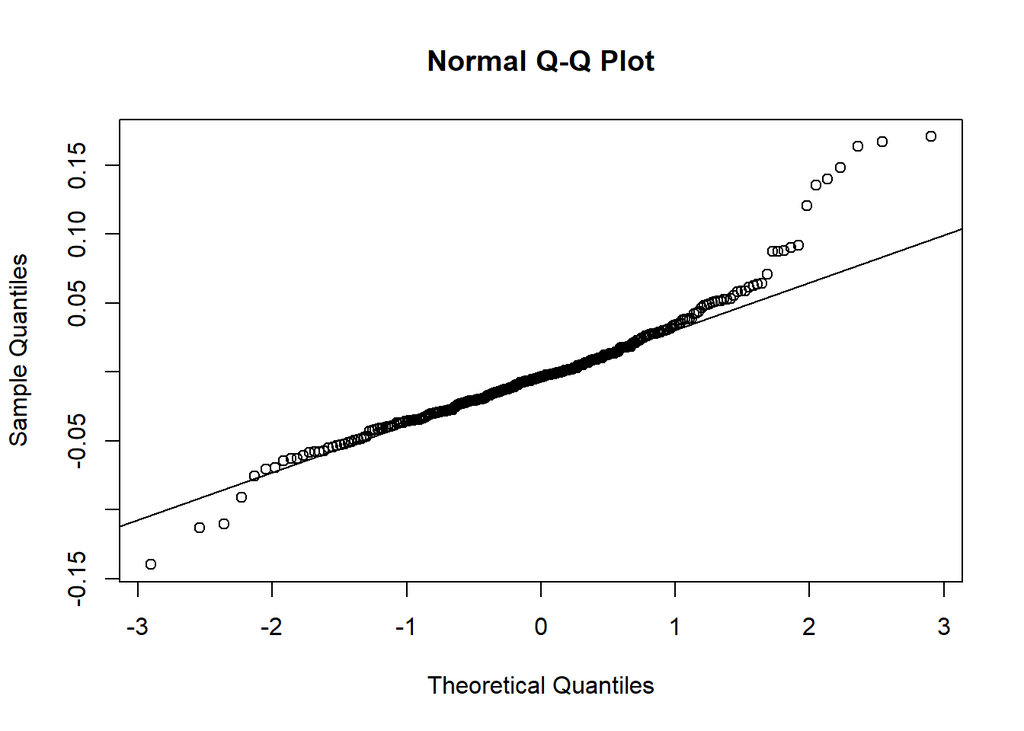

```r
qqnorm(resid)
qqline(resid)
```

```r
shapiro.test(resid)
```

```
##
##  Shapiro-Wilk normality test
##
## data:  resid
## W = 0.93744, p-value = 2.488e-09
```

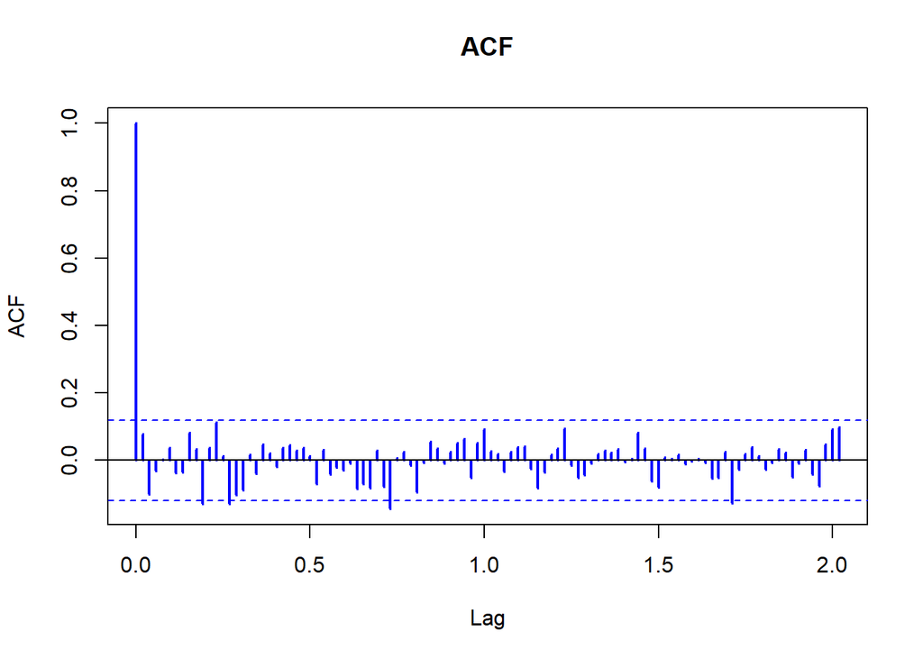

```r
acf(resid, lwd = 2,main = "ACF",col = "blue",lag.max=105)
```

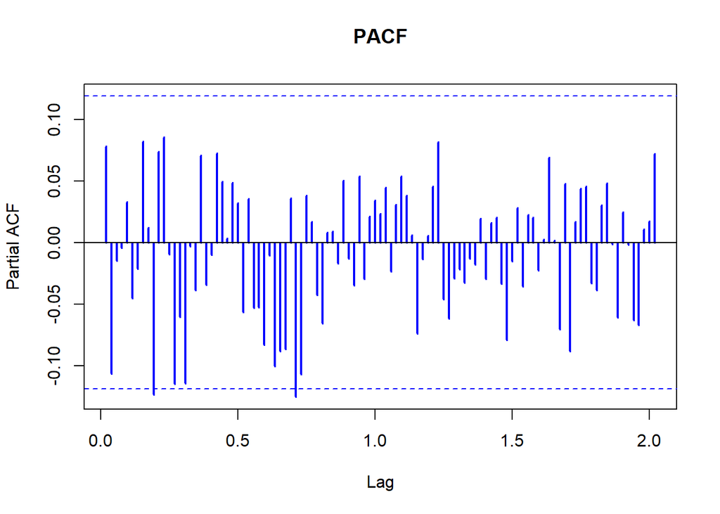

```r
pacf(resid, lwd = 2,main = "PACF",col = "blue",lag.max=105)
```

Остатки не похожи на нормально распределённые, как минимум, правый хвост довольно тяжёлый, автокорреляций в остатках не наблюдается. Сравним с другой моделью:

```r
arima_model <- arima(new_data,order = c(1,0,1),seasonal = list(order= c(0,0,1),period = 52),method = "ML")
coeftest(arima_model)
```

```
##
## z test of coefficients:
##
##            Estimate Std. Error z value  Pr(>|z|)
## ar1       0.5232482  0.0814180  6.4267 1.304e-10 ***
## ma1       0.2124464  0.0947961  2.2411   0.02502 *
## sma1      0.1001700  0.0631464  1.5863   0.11267
## intercept 0.0020979  0.0070085  0.2993   0.76468
## ---
## Signif. codes:  0 '***' 0.001 '**' 0.01 '*' 0.05 '.' 0.1 ' ' 1
```

```r
AIC(arima_model)
```

```
## [1] -939.0921
```

```r
resid <- arima_model$residuals
Box.test(resid, lag = 52, type = "Ljung-Box", fitdf = 2)
```

```
##
##  Box-Ljung test
##
## data:  resid
## X-squared = 50.406, df = 50, p-value = 0.4573
```

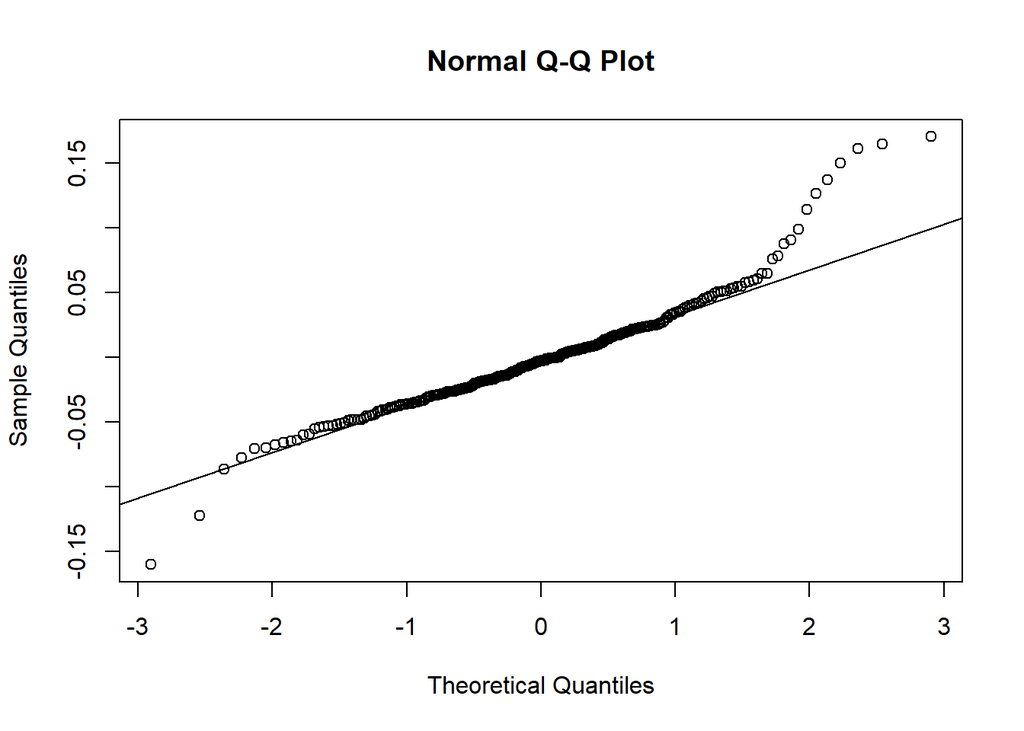

```r
qqnorm(resid)
qqline(resid)
```

```r
shapiro.test(resid)
```

```
##
##  Shapiro-Wilk normality test
##
## data:  resid
## W = 0.9372, p-value = 2.354e-09
```

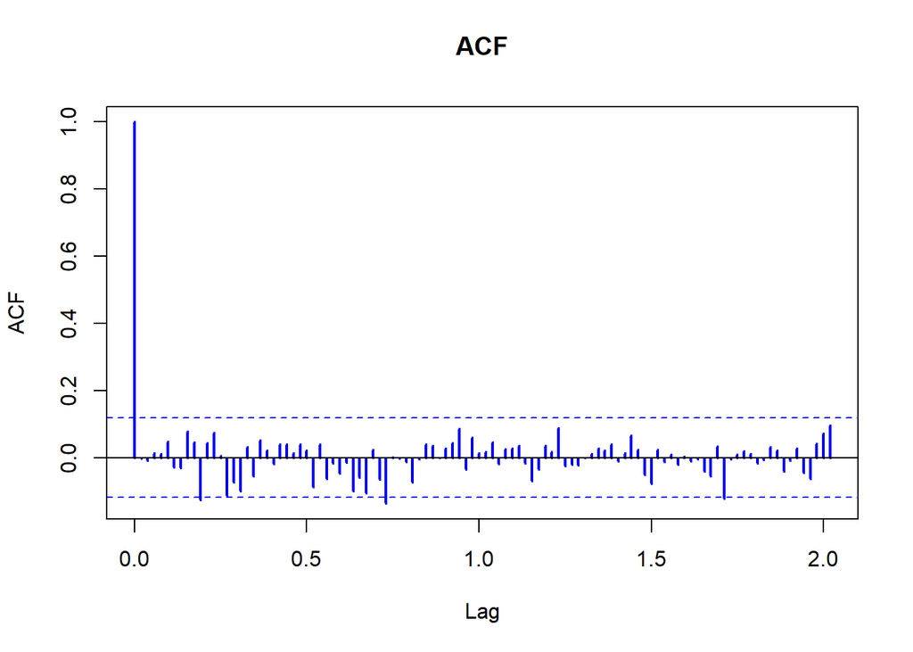

```r
acf(resid, lwd = 2,main = "ACF",col = "blue",lag.max=105)
```

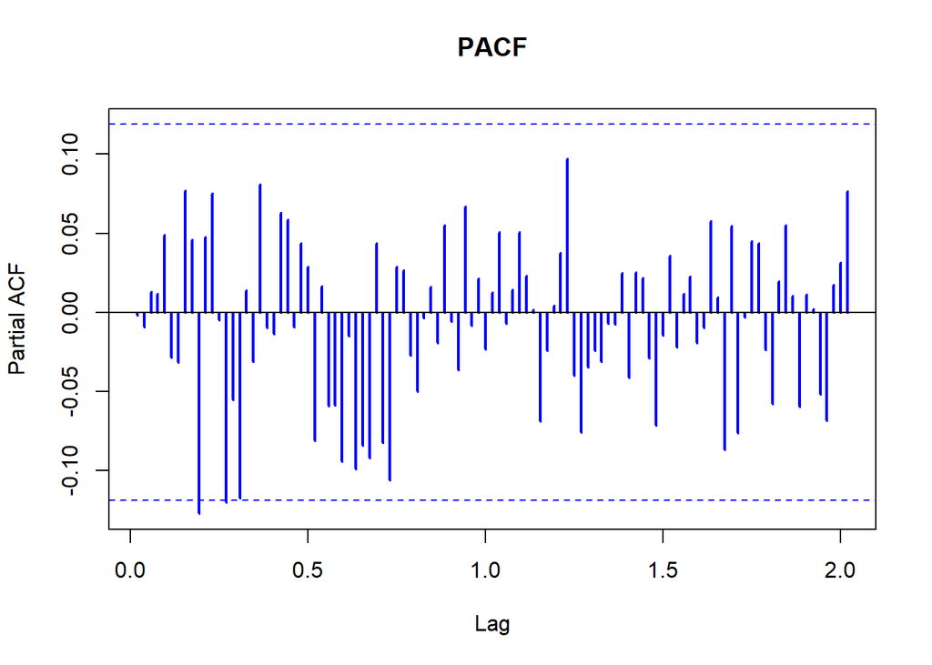

```r
pacf(resid, lwd = 2,main = "PACF",col = "blue",lag.max=105)
```

```r
arima_model <- arima(new_data,order = c(1,0,1),seasonal = list(order= c(0,0,0),period = 52),method = "ML")
coeftest(arima_model)
```

```
##
## z test of coefficients:
##
##            Estimate Std. Error z value  Pr(>|z|)
## ar1       0.5315255  0.0800974  6.6360 3.223e-11 ***
## ma1       0.2141277  0.0945167  2.2655   0.02348 *
## intercept 0.0019629  0.0066380  0.2957   0.76745
## ---
## Signif. codes:  0 '***' 0.001 '**' 0.01 '*' 0.05 '.' 0.1 ' ' 1
```

```r
AIC(arima_model)
```

```
## [1] -938.6259
```

```r
resid <- arima_model$residuals
Box.test(resid, lag = 52, type = "Ljung-Box", fitdf = 2)
```

```
##
##  Box-Ljung test
##
## data:  resid
## X-squared = 55.865, df = 50, p-value = 0.264
```

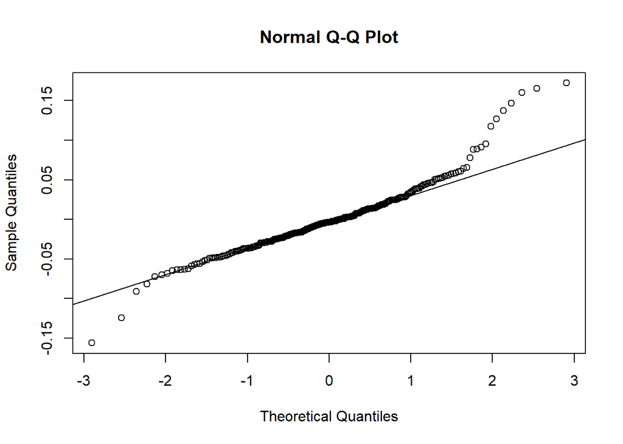

```r
qqnorm(resid)
qqline(resid)
```

```r
shapiro.test(resid)
```

```
##
##  Shapiro-Wilk normality test
##
## data:  resid
## W = 0.93884, p-value = 3.409e-09
```

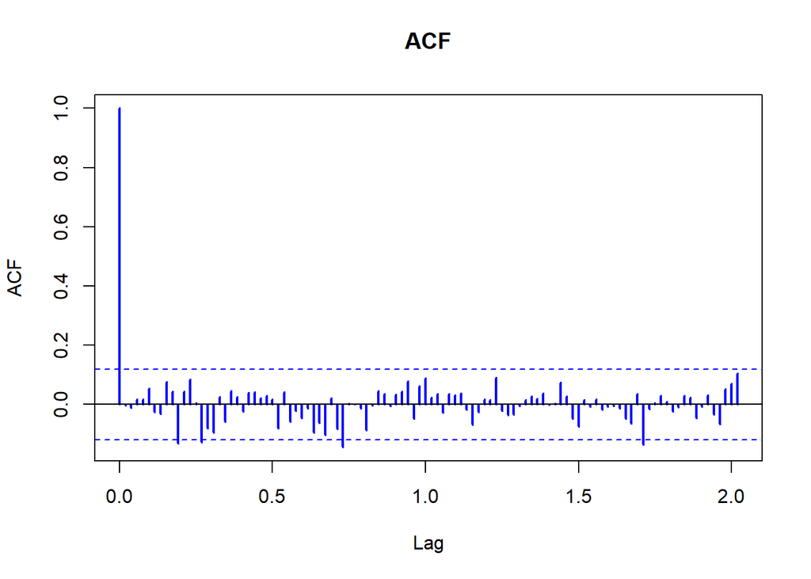

```r
acf(resid, lwd = 2,main = "ACF",col = "blue",lag.max=105)
```

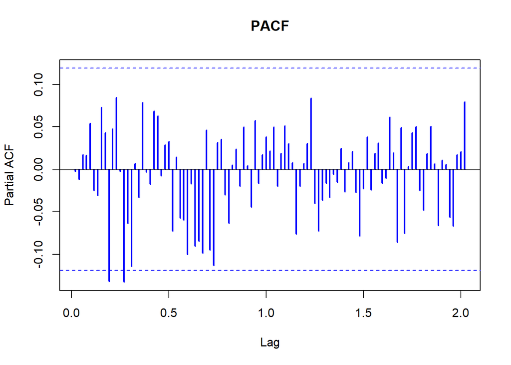

```r
pacf(resid, lwd = 2,main = "PACF",col = "blue",lag.max=105)
```

Отличий практически нет, но зато неинформативной компоненты в модели больше нет, поэтому воспользуемся ею в дальнейшем. Оценим применимость GARCH-модели с помощью теста Энгла:

```r
library(aTSA)
arch.test(arima_model)
```

```
## ARCH heteroscedasticity test for residuals
## alternative: heteroscedastic
##
## Portmanteau-Q test:
##      order   PQ p.value
## [1,]     4 16.5 0.00241
## [2,]     8 19.3 0.01352
## [3,]    12 24.1 0.01985
## [4,]    16 27.2 0.03926
## [5,]    20 36.9 0.01195
## [6,]    24 37.4 0.03996
## Lagrange-Multiplier test:
##      order    LM  p.value
## [1,]     4 185.3 0.00e+00
## [2,]     8  85.1 1.22e-15
## [3,]    12  52.3 2.36e-07
## [4,]    16  35.1 2.40e-03
## [5,]    20  22.5 2.58e-01
## [6,]    24  17.3 7.92e-01
```

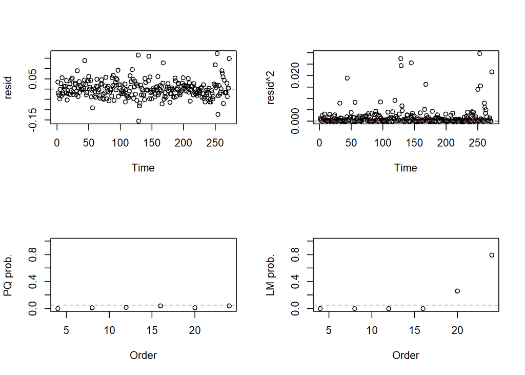

Первый тест отвергает гипотезу о белом шуме на всех задержках. Второй тест не отвергает гипотезы о белом шуме на всех задержках, начиная с 20. Следовательно, GARCH моделЬ применима.

```r
library(rugarch)
```

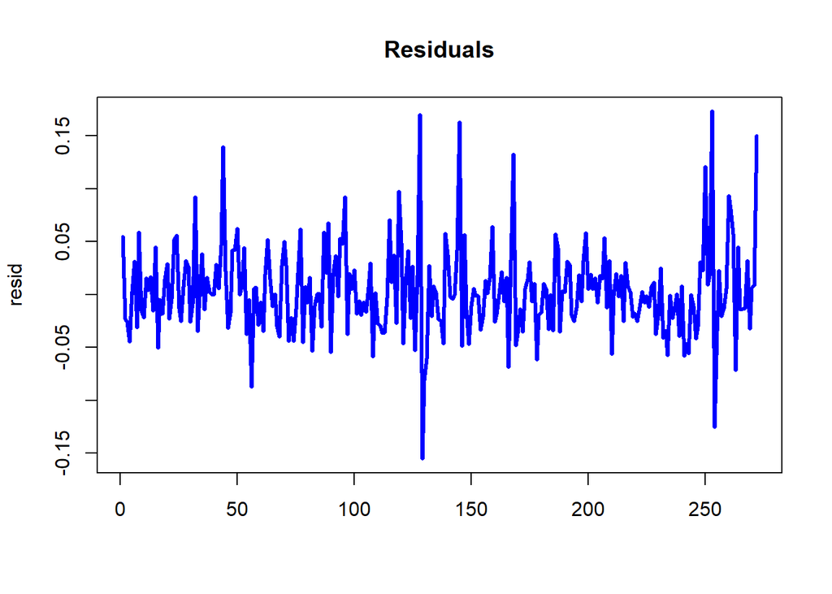

```r
spec <- ugarchspec(variance.model = list(model ="sGARCH",garchOrder = c(1,1)), mean.model = list(armaOrder = c(1, 1)),distribution.model = "std")
fit <- ugarchfit(data = new_data, spec = spec)
resid <- fit@fit$residuals
matplot(resid,type = "l",lwd = 3,col = "blue",main = "Residuals")
```

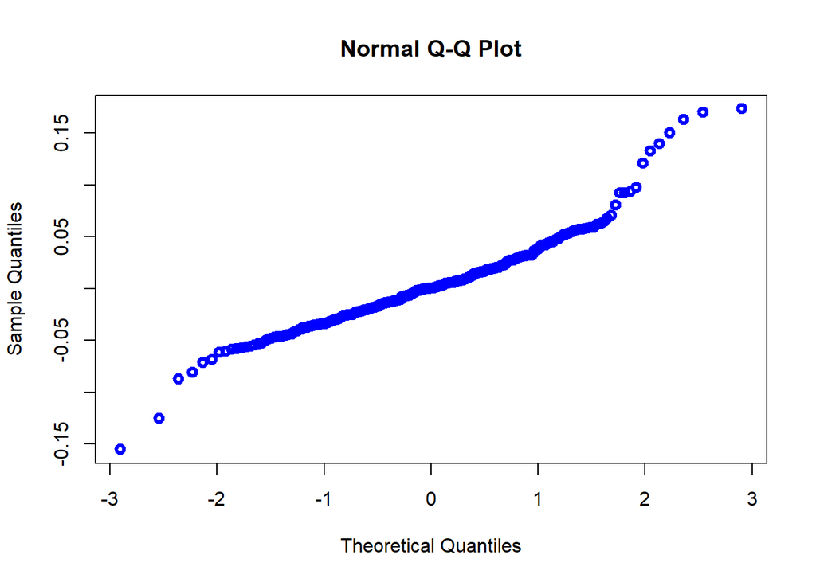

```r
qqnorm(resid ,lwd=3,col = "blue")
```

```r
shapiro.test(resid)
```

```
##
##  Shapiro-Wilk normality test
##
## data:  resid
## W = 0.93947, p-value = 3.936e-09
```

```r
infocriteria(fit)
```

```
##
## Akaike       -3.610244
## Bayes        -3.517448
## Shibata      -3.611525
## Hannan-Quinn -3.572990
```

Методом проб и ошибок определели, что наименьший критерий Акаике получается при указании порядка GARCH модели 1,1. Составим по ней прогноз:

```r
library(fGarch)
```

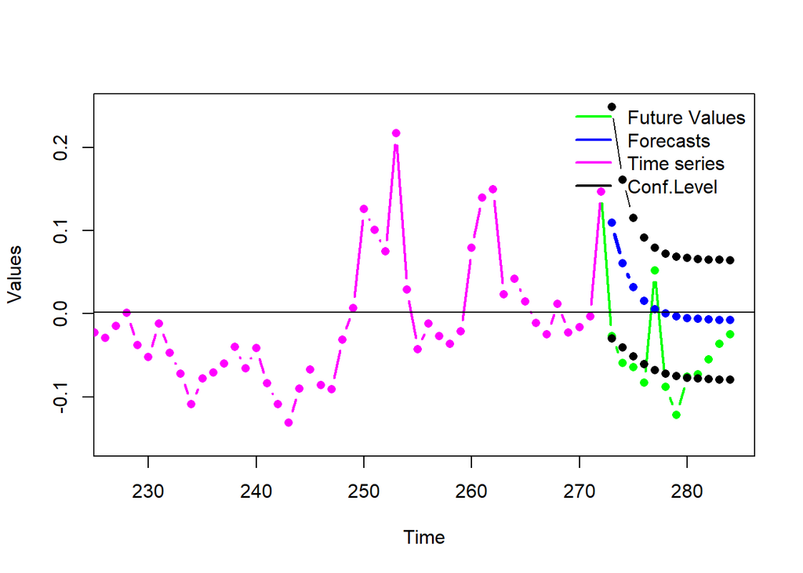

```r
z<- new_data
zz<-window(data,start = c(2014,36), end = c(2014,48))

getVector <- function(vv,bInd,l)
{
c <- vector()
if (bInd > 1)
{
c <- rep(NA,bInd-1)
}
res <- c(c,vv)
cc <- vector()
cc <- rep(NA,l-length(res))
res <- c(res,cc)
return(res)

}
ldf <- length(z)
nforec <- 12
ll <- ldf + nforec
forec<-ugarchforecast(fit,n.ahead = nforec)

vec1 <- getVector(zz,ldf,ll)
vec2 <- getVector(forec@forecast$seriesFor,ldf+1,ll)
vec3 <- getVector(z,1,ll)
q<- qnorm(0.95)
dPl <- forec@forecast$seriesFor + forec@forecast$sigmaFor*q
dMn <- forec@forecast$seriesFor - forec@forecast$sigmaFor*q
vec4 <- getVector(dPl,ldf+1,ll)
vec5 <- getVector(dMn,ldf+1,ll)
res <- cbind(vec1,vec2,vec3,vec4,vec5)
matplot(res , type = c("b","b","b","b","b"),pch = 16,lty=1, lwd= c(2,3,2,1,1),ylab = "Values",xlab="Time",col = c("green","blue","magenta","black","black"), xlim = c(ll*0.8,ll))
abline(h=coef(arima_model)[names(coef(arima_model))=='intercept'])
legend("topright",c("Future Values","Forecasts","Time series","Conf.Level"),bty="n",lwd = 2,col = c("green","blue","magenta","black"))
```

Рассмотрим дополнительный датасет:

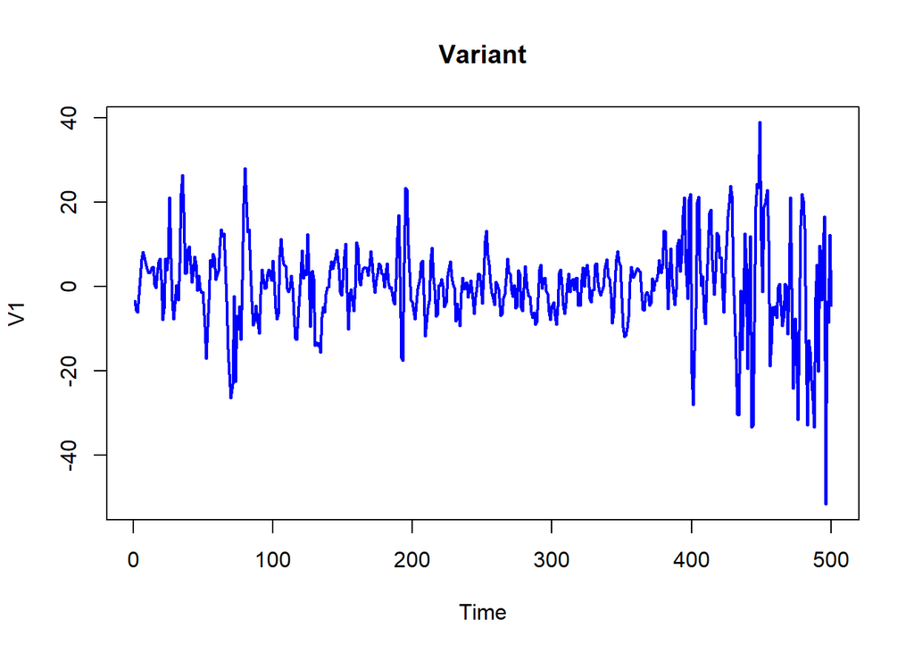

```r
library(tseries)
#variant <- diff(ts(na.omit(read.csv("variant.csv", sep = ",", header = TRUE))[2]))
variant <- ts(na.omit(read.csv("variant.csv", sep = ",", header = TRUE))[2])
#variant <- variant[2:length(variant)] / variant[1:length(variant)-1]-1
plot(variant ,type = "l", col = "blue",lwd = 2,main = "Variant")
```

```r
adf.test(variant)
```

```
## Augmented Dickey-Fuller Test
## alternative: stationary
##
## Type 1: no drift no trend
##      lag    ADF p.value
## [1,]   0 -11.69    0.01
## [2,]   1 -12.59    0.01
## [3,]   2 -10.48    0.01
## [4,]   3 -10.43    0.01
## [5,]   4  -9.38    0.01
## [6,]   5  -9.44    0.01
## Type 2: with drift no trend
##      lag    ADF p.value
## [1,]   0 -11.68    0.01
## [2,]   1 -12.59    0.01
## [3,]   2 -10.48    0.01
## [4,]   3 -10.43    0.01
## [5,]   4  -9.38    0.01
## [6,]   5  -9.44    0.01
## Type 3: with drift and trend
##      lag    ADF p.value
## [1,]   0 -11.71    0.01
## [2,]   1 -12.65    0.01
## [3,]   2 -10.55    0.01
## [4,]   3 -10.51    0.01
## [5,]   4  -9.47    0.01
## [6,]   5  -9.54    0.01
## ----
## Note: in fact, p.value = 0.01 means p.value <= 0.01
```

Судя по полученным p-value, рассматриваемый ряд стационарный. Построим графики ACF и PACF, чтобы определить порядок ARMA модели:

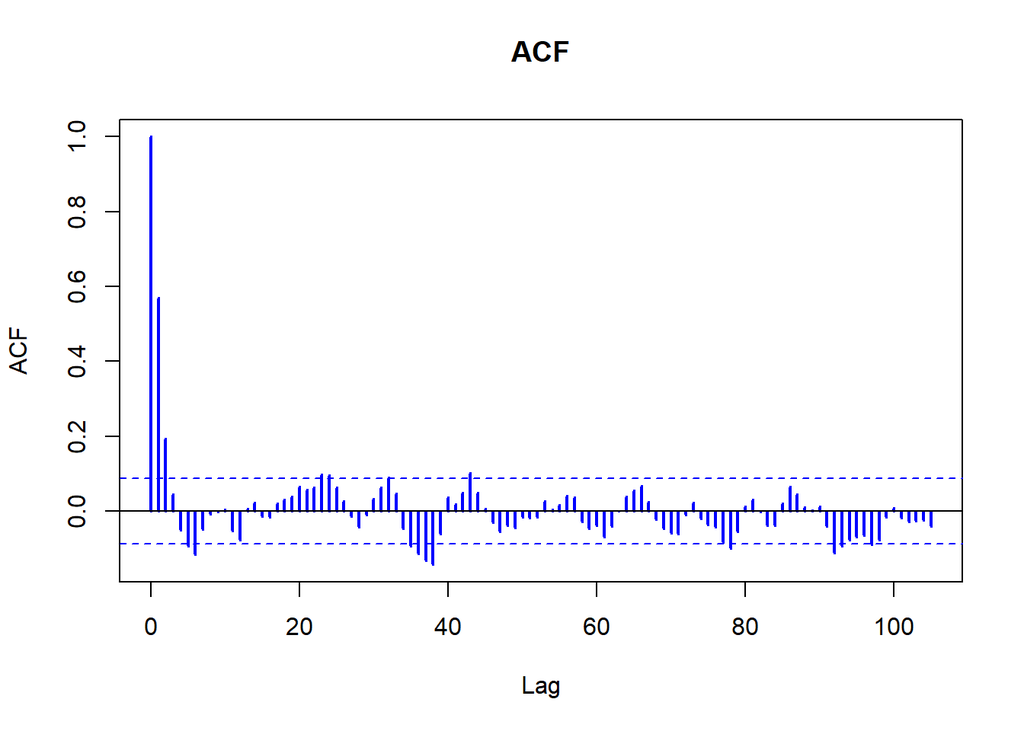

```r
acf(variant, lwd = 2,main = "ACF",col = "blue",lag.max = 105)
```

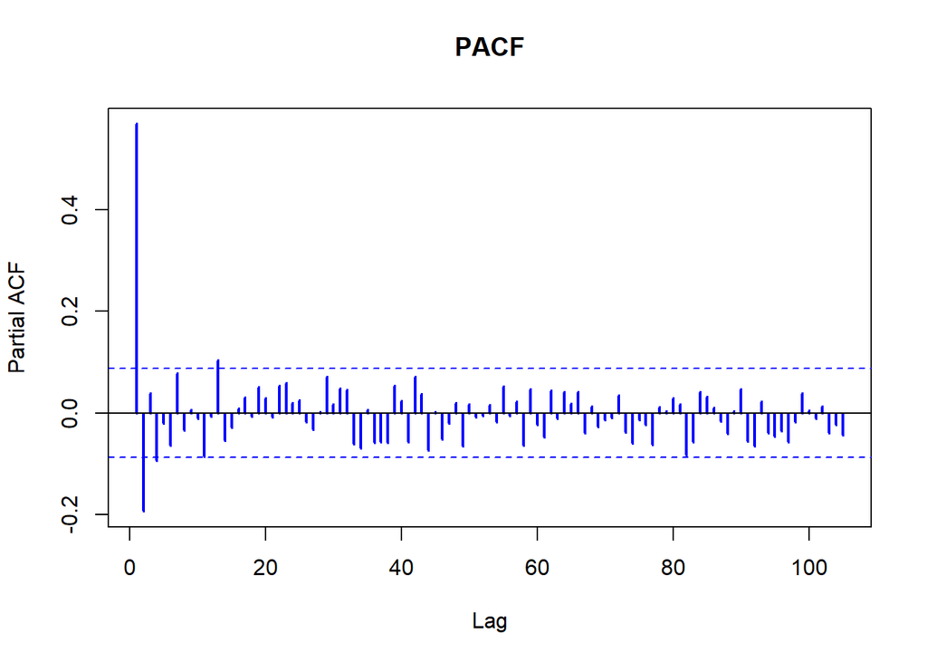

```r
pacf(variant,lwd = 2,main = "PACF",col = "blue",lag.max=105)
```

На всякий случай, для надёжности минимизации по Акаике, воспользуемся автоматическим подбором модели:

```r
auto.arima(variant)
```

```
## Series: variant
## ARIMA(3,0,2) with zero mean
##
## Coefficients:
##          ar1     ar2      ar3     ma1      ma2
##       0.4461  0.5217  -0.3340  0.2720  -0.6262
## s.e.  0.2328  0.0913   0.0787  0.2374   0.2112
##
## sigma^2 = 62.98:  log likelihood = -1743.12
## AIC=3498.24   AICc=3498.41   BIC=3523.53
```

```r
new_arima_model <- arima(variant,order = c(3,0,2),seasonal = list(order= c(0,0,0),period = 52),method = "ML")
coeftest(new_arima_model)
```

```
##
## z test of coefficients:
##
##            Estimate Std. Error z value  Pr(>|z|)
## ar1        0.447928   0.231681  1.9334   0.05319 .
## ar2        0.522496   0.091237  5.7268 1.023e-08 ***
## ar3       -0.335263   0.078349 -4.2791 1.876e-05 ***
## ma1        0.269572   0.236306  1.1408   0.25396
## ma2       -0.628655   0.210256 -2.9899   0.00279 **
## intercept  0.246958   0.620698  0.3979   0.69073
## ---
## Signif. codes:  0 '***' 0.001 '**' 0.01 '*' 0.05 '.' 0.1 ' ' 1
```

```r
AIC(new_arima_model)
```

```
## [1] 3500.084
```

```r
resid <- new_arima_model$residuals
Box.test(resid, lag = 52, type = "Ljung-Box", fitdf = 5)
```

```
##
##  Box-Ljung test
##
## data:  resid
## X-squared = 52.142, df = 47, p-value = 0.2808
```

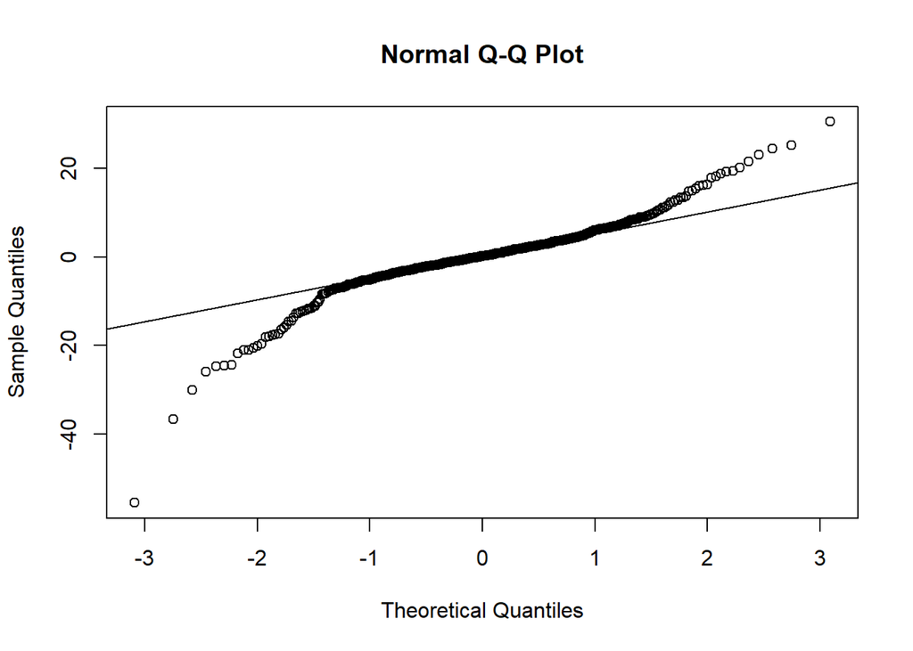

```r
qqnorm(resid)
qqline(resid)
```

```r
shapiro.test(resid)
```

```
##
##  Shapiro-Wilk normality test
##
## data:  resid
## W = 0.90196, p-value < 2.2e-16
```

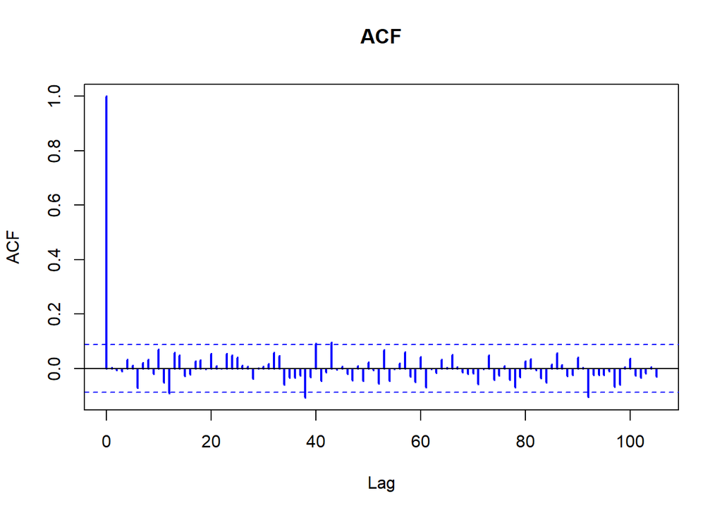

```r
acf(resid, lwd = 2,main = "ACF",col = "blue",lag.max=105)
```

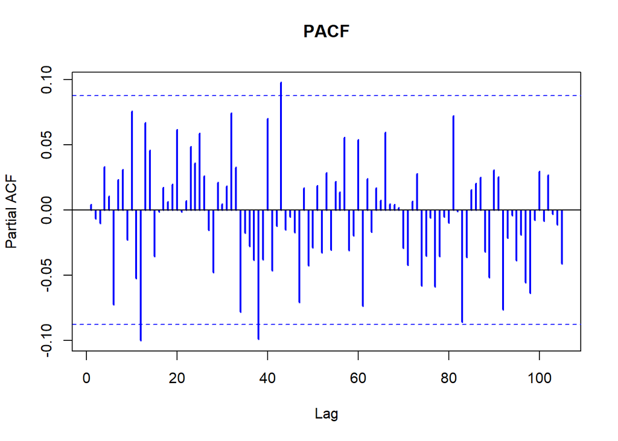

```r
pacf(resid, lwd = 2,main = "PACF",col = "blue",lag.max=105)
```

```r
arch.test(new_arima_model)
```

```
## ARCH heteroscedasticity test for residuals
## alternative: heteroscedastic
##
## Portmanteau-Q test:
##      order  PQ p.value
## [1,]     4 153       0
## [2,]     8 209       0
## [3,]    12 236       0
## [4,]    16 257       0
## [5,]    20 269       0
## [6,]    24 280       0
## Lagrange-Multiplier test:
##      order    LM  p.value
## [1,]     4 327.3 0.00e+00
## [2,]     8 116.2 0.00e+00
## [3,]    12  72.1 4.81e-11
## [4,]    16  46.5 4.35e-05
## [5,]    20  36.0 1.06e-02
## [6,]    24  27.2 2.46e-01
```

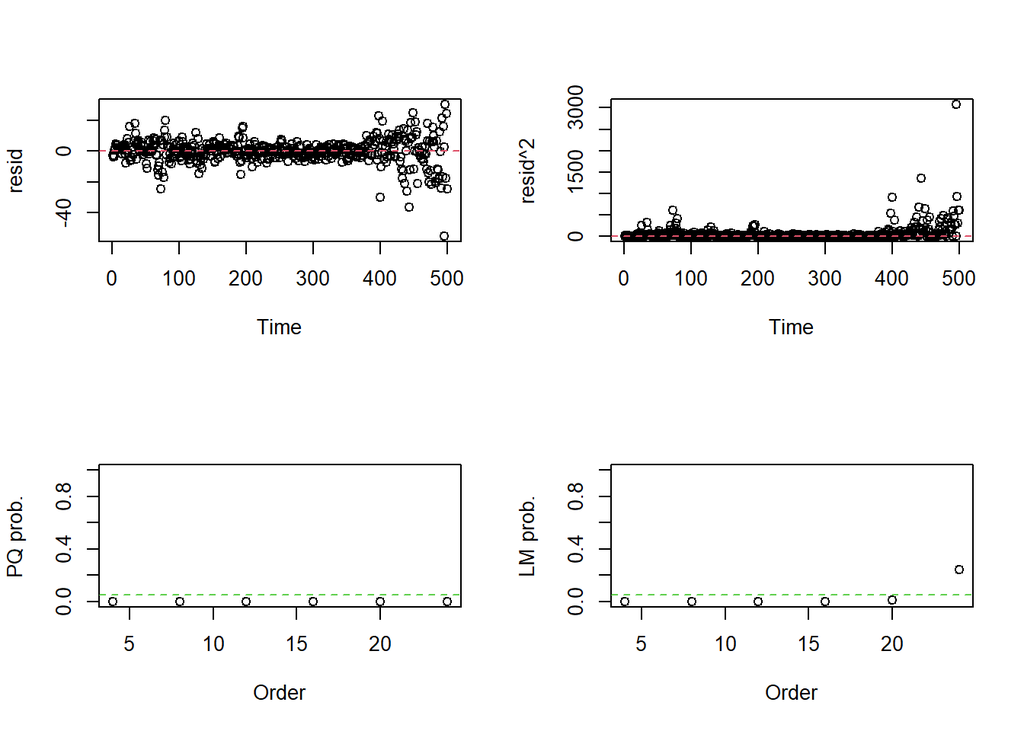

Первый тест отвергает гипотезу о белом шуме, второй отвергает на всех задержках, кроме 24. Можно считать, что гетероскедастичность применима. Ниже произведён подбор порядков ARIMA-sGARCH модели с минимальным значением критерия Акаике:

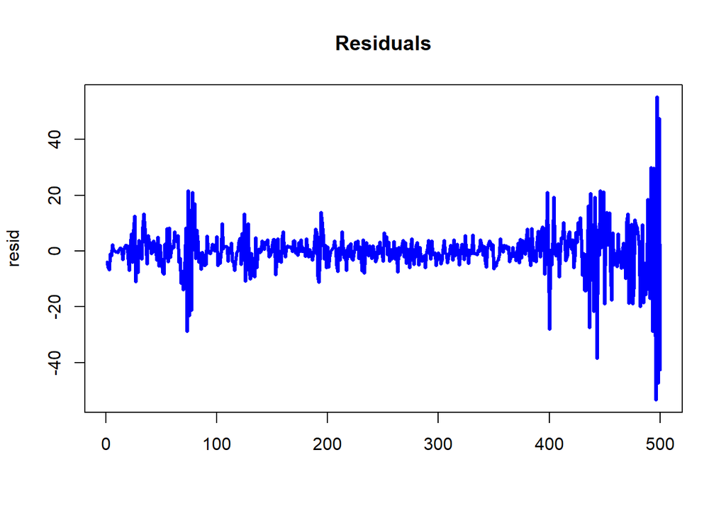

```r
spec <- ugarchspec(variance.model = list(model ="sGARCH",garchOrder = c(2,1)), mean.model = list(armaOrder = c(3, 2)),distribution.model = "std")
fit <- ugarchfit(data = variant, spec = spec)
resid <- fit@fit$residuals
matplot(resid,type = "l",lwd = 3,col = "blue",main = "Residuals")
```

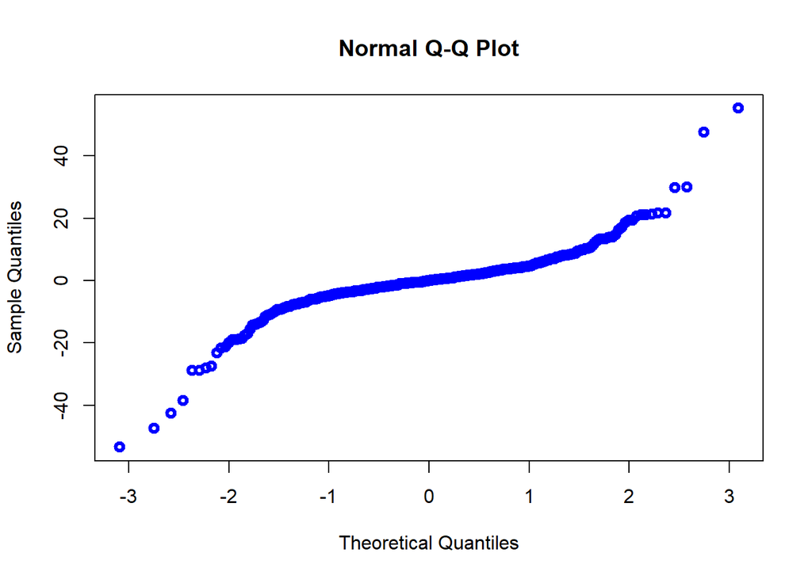

```r
qqnorm(resid ,lwd=3,col = "blue")
```

```r
shapiro.test(resid)
```

```
##
##  Shapiro-Wilk normality test
##
## data:  resid
## W = 0.82354, p-value < 2.2e-16
```

```r
infocriteria(fit)
```

```
##
## Akaike       6.183031
## Bayes        6.275752
## Shibata      6.182091
## Hannan-Quinn 6.219415
```

Остатки не распределены нормально, что говорит о плохой подгонке модели. Попробуем продифференцировать ряд, а также рассмотреть относительные приросты:

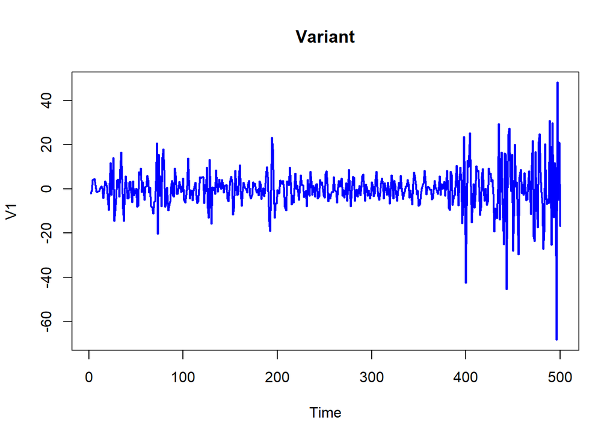

```r
variant <- diff(ts(na.omit(read.csv("variant.csv", sep = ",", header = TRUE))[2]))
plot(variant ,type = "l", col = "blue",lwd = 2,main = "Variant")
```

```r
adf.test(variant)
```

```
## Augmented Dickey-Fuller Test
## alternative: stationary
##
## Type 1: no drift no trend
##      lag   ADF p.value
## [1,]   0 -23.7    0.01
## [2,]   1 -21.5    0.01
## [3,]   2 -17.1    0.01
## [4,]   3 -16.2    0.01
## [5,]   4 -14.0    0.01
## [6,]   5 -15.4    0.01
## Type 2: with drift no trend
##      lag   ADF p.value
## [1,]   0 -23.6    0.01
## [2,]   1 -21.5    0.01
## [3,]   2 -17.1    0.01
## [4,]   3 -16.1    0.01
## [5,]   4 -14.0    0.01
## [6,]   5 -15.4    0.01
## Type 3: with drift and trend
##      lag   ADF p.value
## [1,]   0 -23.6    0.01
## [2,]   1 -21.4    0.01
## [3,]   2 -17.0    0.01
## [4,]   3 -16.1    0.01
## [5,]   4 -14.0    0.01
## [6,]   5 -15.4    0.01
## ----
## Note: in fact, p.value = 0.01 means p.value <= 0.01
```

Судя по полученным p-value, ряд из разностей стационарный. Построим графики ACF и PACF, чтобы определить порядок ARMA модели:

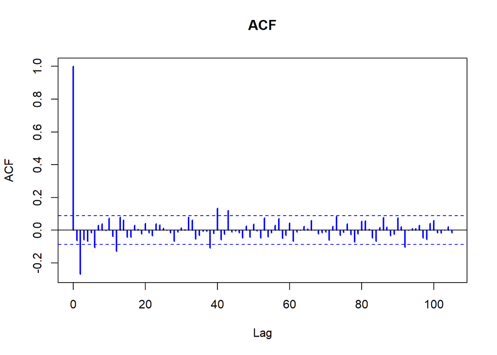

```r
acf(variant, lwd = 2,main = "ACF",col = "blue",lag.max = 105)
```

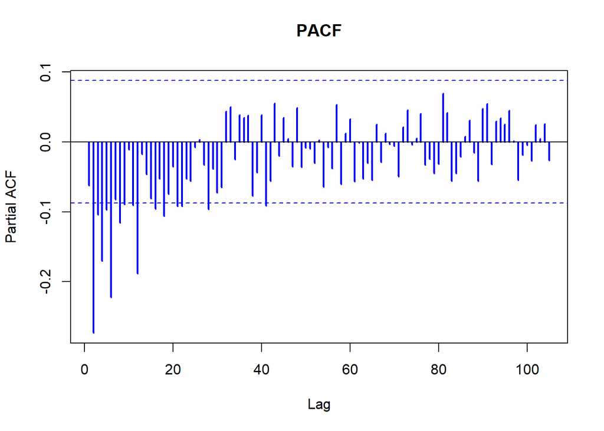

```r
pacf(variant,lwd = 2,main = "PACF",col = "blue",lag.max=105)
```

Снова воспользуемся автоматическим подбором модели:

```r
auto.arima(variant)
```

```
## Series: variant
## ARIMA(0,0,1) with non-zero mean
##
## Coefficients:
##           ma1    mean
##       -0.1479  0.0024
## s.e.   0.0711  0.3517
##
## sigma^2 = 85.28:  log likelihood = -1816.32
## AIC=3638.63   AICc=3638.68   BIC=3651.27
```

На графике явно видно, что порядок модели больше, чем предлагает функция автоматического подбора, поэтому выберем модель порядка (0,0,2) без сезонной компоненты.

```r
new_arima_model <- arima(variant,order = c(0,0,2),seasonal = list(order= c(0,0,0),period = 52),method = "ML")
coeftest(new_arima_model)
```

```
##
## z test of coefficients:
##
##             Estimate Std. Error  z value Pr(>|z|)
## ma1       -0.3551626  0.0388768  -9.1356   <2e-16 ***
## ma2       -0.6448373  0.0384793 -16.7580   <2e-16 ***
## intercept -0.0053693  0.0041301  -1.3001   0.1936
## ---
## Signif. codes:  0 '***' 0.001 '**' 0.01 '*' 0.05 '.' 0.1 ' ' 1
```

Как видим, не зря. Компонента второго порядка оказалась значимой.

```r
AIC(new_arima_model)
```

```
## [1] 3519.195
```

```r
resid <- new_arima_model$residuals
Box.test(resid, lag = 52, type = "Ljung-Box", fitdf = 2)
```

```
##
##  Box-Ljung test
##
## data:  resid
## X-squared = 78.494, df = 50, p-value = 0.006173
```

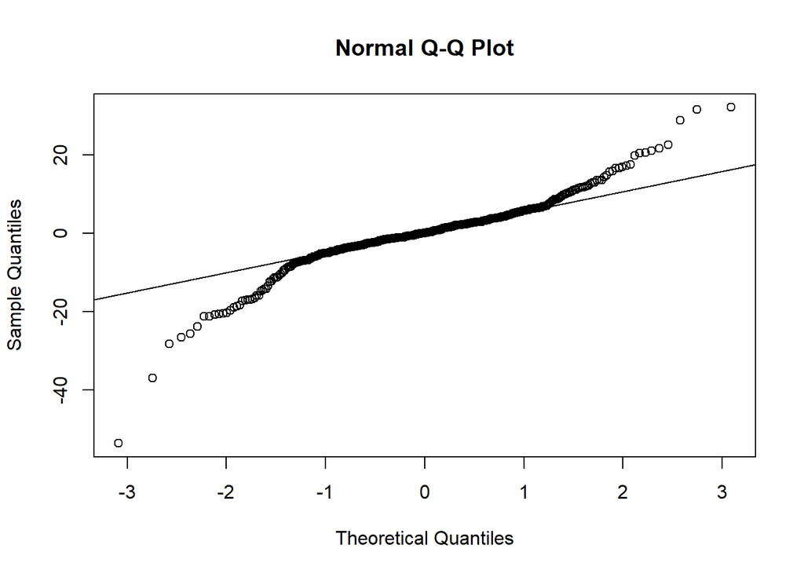

```r
qqnorm(resid)
qqline(resid)
```

```r
shapiro.test(resid)
```

```
##
##  Shapiro-Wilk normality test
##
## data:  resid
## W = 0.90875, p-value < 2.2e-16
```

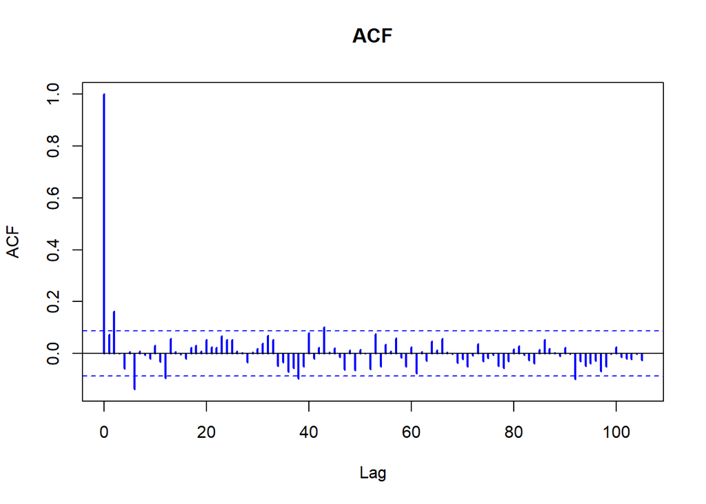

```r
acf(resid, lwd = 2,main = "ACF",col = "blue",lag.max=105)
```